## Process ONT UMI data from Zymomock rRNA amplicons

Last updated 2020-02-19

**Reference**

- SM Karst, RM Ziels, RH Kirkegaard, EA Sørensen, D. McDonald, Q Zhu, R Knight, & M Albertsen. (2020). Enabling high-accuracy long-read amplicon sequences using unique molecular identifiers with Nanopore or PacBio sequencing. [bioRxiv, 6459039](https://www.biorxiv.org/content/10.1101/645903v3).
- Important: The longread_umi pipeline has been updated since the data was generated for the bioRxiv paper. The updates produces more UMI sequences from the same raw data, which has a small impact on the reported error and chimera rates. However, it does not impact the overall conclusions.

**Sample**

- ZymoBIOMICS Microbial Community DNA Standard (D6306, lot no. ZRC190811, Zymo Research)
- 8 bacterial species: Bacillus subtilis, Enterococcus faecalis, Escherichia coli, Lactobacillus fermentum, Listeria monocytogenes, Pseudomonas aeruginosa, Salmonella enterica, Staphylococcus aureus.

**Library**

- [UMI amplicon protocol at Protocols.io](https://www.protocols.io/private/F5C5FE21305911EAAC0B0242AC110003)
- rRNA PCR primers: [8F] 5’-AGRGTTYGATYMTGGCTCAG and [2490R] 5’-CGACATCGAGGTGCCAAAC
- Library: 1D amplicon/cDNA by ligation (SQK-LSK109)

**Sequencing**

- Flowcell: R10
- Instrument: MinION
- Basecalling: guppy v3.4.4 with HAC model

### Generate UMI consensus sequences in BASH terminal

Download and decompress data

```bash
wget "ftp://ftp.sra.ebi.ac.uk/vol1/run/ERR381/ERR3813594/smkj412_zymo_D6306_rrna_umi_ont_min_r10_g344hac.fq.gz"
gunzip -c smkj412_zymo_D6306_rrna_umi_ont_min_r10_g344hac.fq.gz > reads.fq

wget "https://www.arb-silva.de/fileadmin/silva_databases/release_132/Exports/SILVA_132_SSURef_Nr99_tax_silva.fasta.gz"
gunzip -c SILVA_132_SSURef_Nr99_tax_silva.fasta.gz | sed '/^>/! s/U/T/g' > silva_db.fasta
rm SILVA_132_SSURef_Nr99_tax_silva.fasta.gz
```

Generate UMI consensus sequences from raw read data

```bash
longread_umi nanopore_pipeline \
  -d reads.fq \
  -o umi_out \
  -v 25 \
  -q r10_min_high_g340 \
  -m 3500 \
  -M 6000 \
  -s 90 \
  -e 90 \
  -f CAAGCAGAAGACGGCATACGAGAT \
  -F AGRGTTYGATYMTGGCTCAG \
  -r AATGATACGGCGACCACCGAGATC \
  -R CGACATCGAGGTGCCAAAC \
  -c 2 \
  -p 2 \
  -t 10 \
  -T 1
```

Generate validation data from UMI consensus sequences

```bash
longread_umi qc_pipeline \
-d "reads.fq" \
-c "umi_out/consensus_raconx2_medakax2.fa;umi_out/variants.fa" \
-r "zymo_curated" \
-s silva_db.fasta \
-u umi_out \
-o umi_out/qc \
-t 10
```

## Validate UMI consensus sequences in R-terminal

Load longread_umi functions and create working directory

```r
source("longread_umi/scripts/validation_functions.R")
# Conda path: $CONDA_PREFIX/longread_umi/scripts/validation_functions.R"
dir.create("./validation")
```

Compile validation data and generate error profile

```r
lu_compile_qc(
  data_dir = "umi_out/qc",
  umi_consensus = "consensus_raconx2_medakax2.fa",
  reference = "zymo-ref-uniq_2019-10-28.fa",
  read_orientation = "read_orientation.txt",
  silva = "ssu_silva_db.fa",
  out_path = "validation/ONT_R10_ZYMO_rRNA_qc.Rdata"
)
load("validation/ONT_R10_ZYMO_rRNA_qc.Rdata")

ep <- lu_error_profile(
  refs = "umi_out/qc/zymo-ref-uniq_2019-10-28.fa",
  sam = "umi_out/qc/consensus_raconx2_medakax2.sam"
)
save(ep, file = "validation/ONT_R10_ZYMO_rRNA_ep.Rdata")
```

Or load pregenerated data (e.g. longread_umi/docs/rdata/)

```r
load("validation/ONT_R10_ZYMO_rRNA_qc.Rdata")
load("validation/ONT_R10_ZYMO_rRNA_ep.Rdata")
```

Remove UMI sequences without primers in both ends

```r
qc <- filter(
  qc,
  !is.na(length) # remove umi bins where one or both gene specific primers was not found in the consensus sequence.
)

ep <- filter(
  ep,
  sub(";.*","", qname) %in% qc$umi
)
```

### Basic data characteristics

Plot read size distribution.

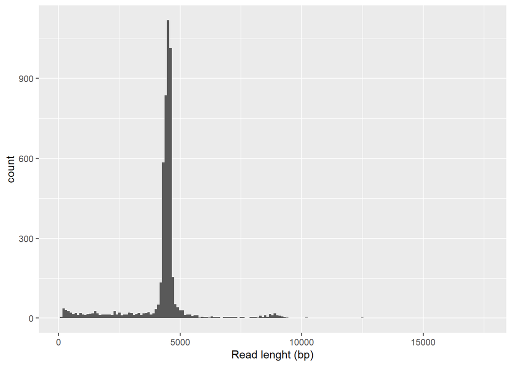

```r
lu_plot_hist(
  value = read_lengths,
  bin_width = 100
  ) +
  xlab(label = "Read lenght (bp)")
```

Plot UMI cluster size distribution.

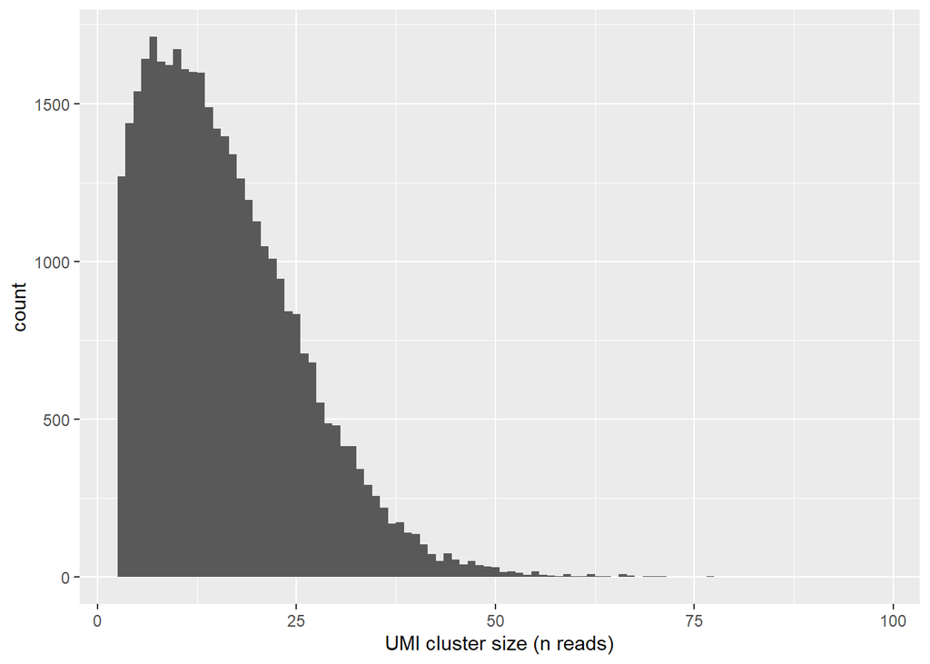

```r
lu_plot_hist(qc$umi_cluster_size, 1) +
  xlab(label = "UMI cluster size (n reads)")
```

Plot UMI bin size distribution

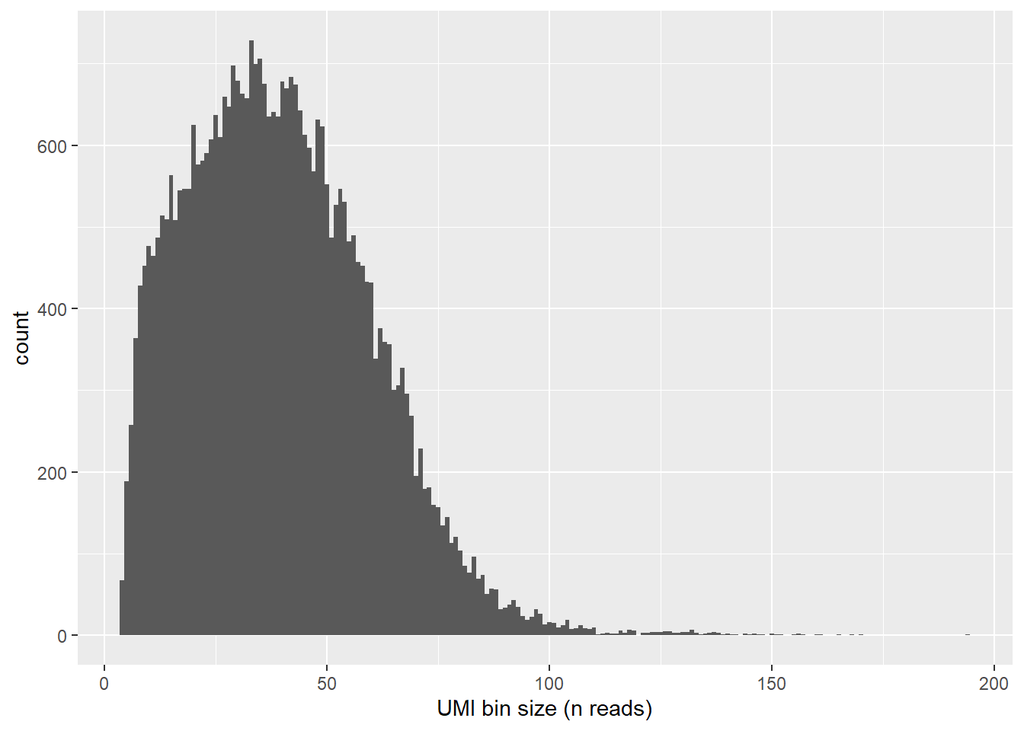

```r
lu_plot_hist(
  qc$umi_bin_size,
  1
) +
  xlab(label = "UMI bin size (n reads)")
```

UMI Bin size statistics.

```r
summary(qc$umi_bin_size)
```

```
##    Min. 1st Qu.  Median    Mean 3rd Qu.    Max.
##    4.00   24.00   38.00   39.44   53.00  194.00
```

Ratio between UMI cluster size and UMI bin size. Median around 2.4.

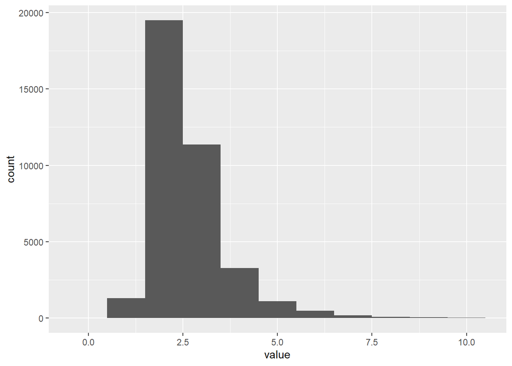

```r
lu_plot_hist(
  qc$umi_bin_size/qc$umi_cluster_size,
  1
)
```

### Error profiling

Error rate versus UMI bin size of unfiltered data. Blue points are flagged as outliers and should be inspected to classify them as `contamination`, `chimeras` or `unknown`.

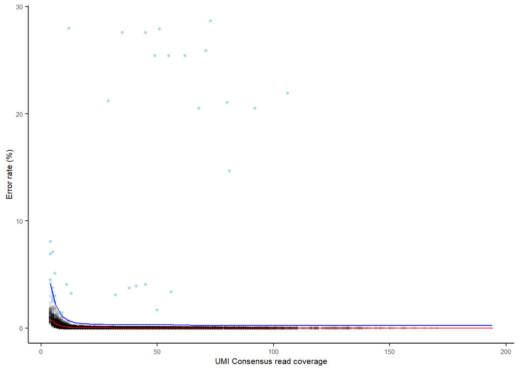

```r
lu_artefact_plot(
  qc,
  breaks = c(seq(1,60,3), Inf)
  ) +
  ylab("Error rate (%)") +
  xlab("UMI Consensus read coverage")
```

The `contamination` in this data originates from the PCR reagents and should be removed before calculating error rates. UMI sequences are classified as contamination if the errors are evenly distributed and if a better match for the SSU part of the operon is found in the Silva database compared to the Zymo reference. `Chimeras` originate from the PCR it self, and these are removed from the data and reported seperately. Chimeras are classified if called by uchime2_ref and if errors are concentrated in either end of the sequence. `Unknown` can’t be classified as either contamination or chimeras and are therefore kept in the dataset.

Extract outlier data.

```r
outlier <- lu_artefact_plot(
  qc,
  breaks = c(seq(1,60,3), Inf)
  ) %>%
  .$data %>%
  filter(
    aflag == "lightblue"
  )
```

Detect contamination sequences. Compare error rates for the SSU part of the operon as calculated based on the Zymo references and the Silva database for the flagged UMI sequences.

```r
cont <- outlier %>%
  select(umi, ref_ssu_error, silva_ssu_error) %>%
  filter(silva_ssu_error < ref_ssu_error &  0.1 < ref_ssu_error - silva_ssu_error) %>%
  arrange(desc(ref_ssu_error - silva_ssu_error)) %>%
  mutate(flag = "cont")

cont %>%
  select(umi, ref_ssu_error, silva_ssu_error)
```

```
## # A tibble: 21 x 3
##    umi           ref_ssu_error silva_ssu_error
##    <chr>                 <dbl>           <dbl>
##  1 umi154222bins          25.2           0.221
##  2 umi103508bins          25.2           0.294
##  3 umi164661bins          19.4           0
##  4 umi45744bins           19.3           0.369
##  5 umi5718bins            19.0           0.222
##  6 umi235356bins          19.1           0.369
##  7 umi7739bins            19.1           0.369
##  8 umi173392bins          18.3           0
##  9 umi175760bins          18.3           0
## 10 umi17619bins           18.1           0
## # ... with 11 more rows
```

Detect chimeras sequences. UMI sequences determined to be contamination above are subtracted from the list of chimeric sequences detected by uchime2_ref.

```r
chi <- outlier %>%
  select(umi, chimera) %>%
  filter(chimera == "Y" & !(umi %in% cont$umi)) %>%
  mutate(flag = "chi")

chi %>%
  select(umi, chimera)
```

```
## # A tibble: 4 x 2
##   umi           chimera
##   <chr>         <chr>
## 1 umi10591bins  Y
## 2 umi162624bins Y
## 3 umi178820bins Y
## 4 umi192992bins Y
```

Inspect classified sequences and if necessary manually curate classifications.

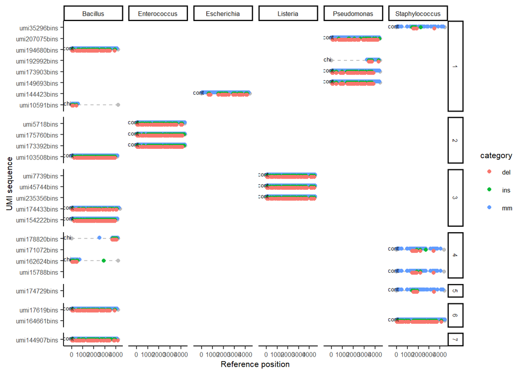

```r
lu_errorpos_plot(
  ep,
  left_join(bind_rows(cont[c("umi", "flag")], chi[c("umi", "flag")]), qc, by = "umi"),
  species = "",
  flag = "flag"
) +
  xlab(label = "Reference position") +
  ylab(label = "UMI sequence")
```

Plot contamination and chimeras for Bacillus only.

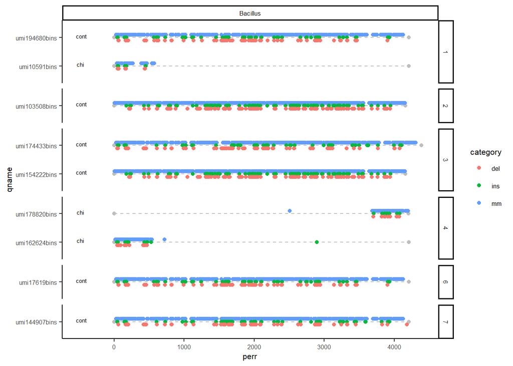

```r
lu_errorpos_plot(
  ep,
  left_join(bind_rows(cont[c("umi", "flag")], chi[c("umi", "flag")]), qc, by = "umi"),
  species = "Bacillus",
  flag= "flag"
)
```

Calculate chimera rate.

```r
qc %>%
filter(
  !(umi %in% cont$umi),
) %>%
  {nrow(chi)/nrow(.)*100}
```

```
## [1] 0.01069748
```

Filter data to remove chimeras and contamination

```r
qcf <- filter(
  qc,
  !(umi %in% cont$umi),
  !(umi %in% chi$umi)
)
epf <- filter(
  ep,
  !(sub(";.*", "", qname) %in% cont$umi),
  !(sub(";.*", "", qname)  %in% chi$umi)
)
```

Error rate versus UMI bin size of filtered data.

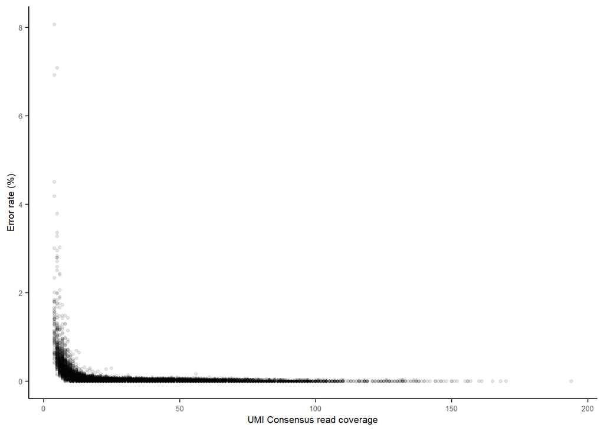

```r
lu_error_plot(
  qcf
  ) +
  ylab("Error rate (%)") +
  xlab("UMI Consensus read coverage")
```

Plot UMI bin size versus error types of filtered data.

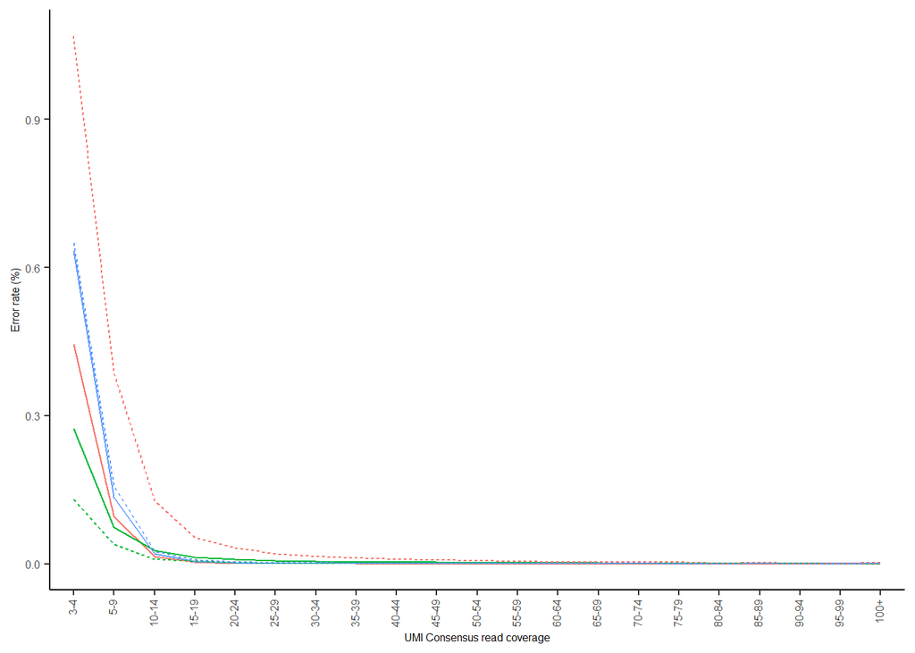

```r
lu_errortype_plot(
  epf,
  ref_hp
  ) +
  ylab("Error rate (%)") +
  xlab("UMI Consensus read coverage")
```

Error rate versus UMI bin size intervals of filtered data

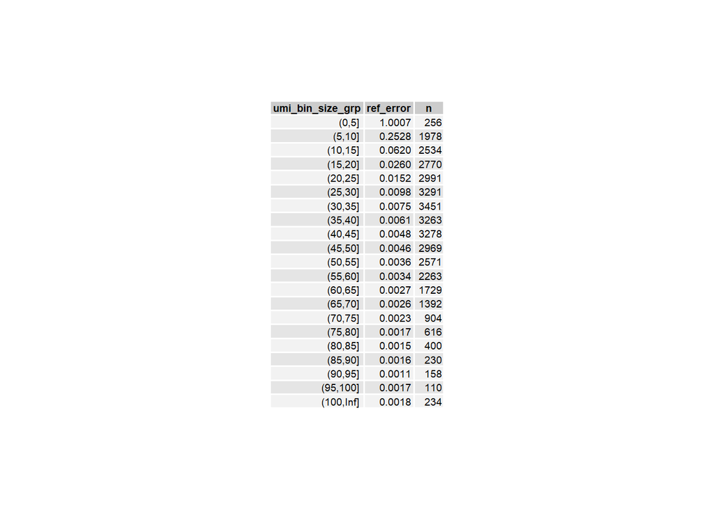

```r
lu_error_plot_tbl(qcf)
```

Filter data < 25x UMI bin size.

```r
qcff <- filter(
  qcf,
  umi_bin_size >= 25
)
epff <- filter(
  epf,
  sub(";.*", "", qname) %in% qcff$umi,
)

qcff %>%
  summarise(
    `UMI sequences (n)` = n(),
    `Mean error rate (%)` = sum(ref_error)/n()
    )
```

```
## # A tibble: 1 x 2
##   `UMI sequences (n)` `Mean error rate (%)`
##                 <int>                 <dbl>
## 1               27496               0.00531
```

Error type summary for >=25x data.

```r
lu_errortype_summary(
  profile = epff,
  digits = 4,
  title = NULL
)
```

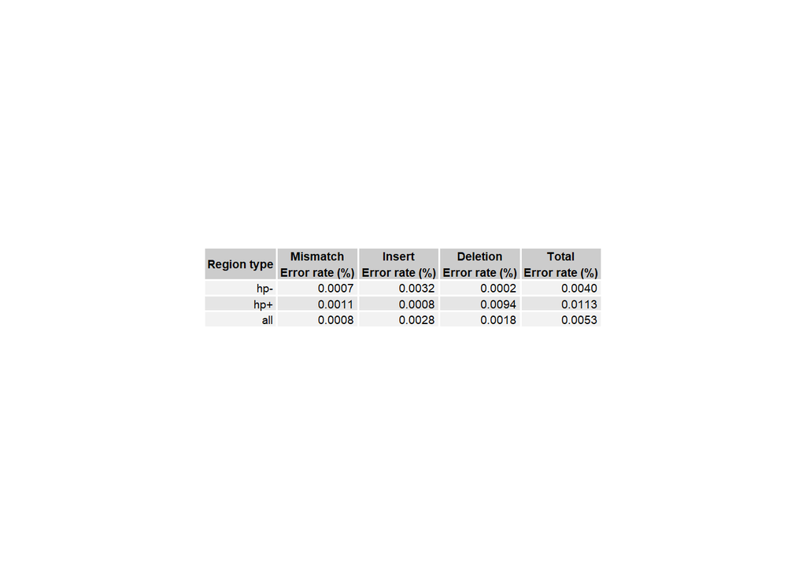

Plot error frequency pr position of Salmonella operon 7 for >=25x data.

```r
lu_ref_error_frequency(
  profile= epff,
  species = "Salmonella_7",
  lower_cut_off = 0.01,
  label_cut_off = 0.02,
  label_col = "type",
  ylim = c(0,1)
)
```

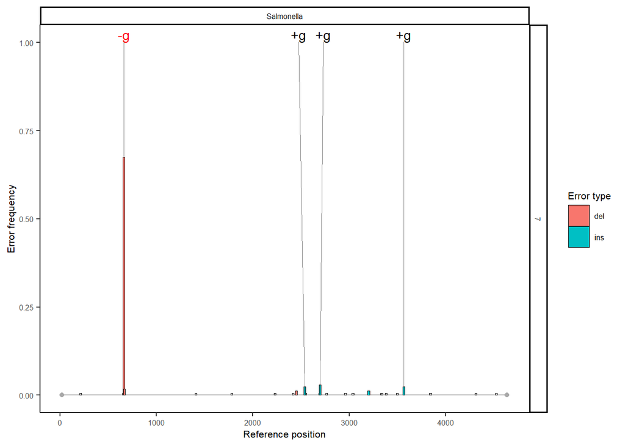

Error counts divided by operon for >=25x data.

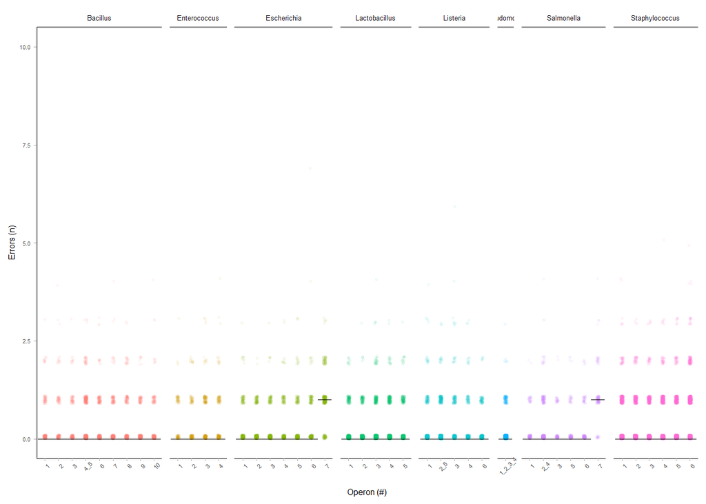

```r
lu_ref_error_plot(
  profile = epff
) +
  ylim(0,10)
```